# Notebook

```python
#1: Setup and Installation
!pip install numpy==1.24.4
!pip install scikit-surprise
!pip install gradio
!pip install openai
```

[output not shown]

```python
# Importing necessary Libraries
import kagglehub
import os
import gradio as gr
import pandas as pd
import numpy as np
from surprise import Dataset, Reader, SVD
from surprise.model_selection import train_test_split
from surprise import accuracy
from openai import OpenAI
import csv  # For handling CSV quoting
```

This code cell downloads the Book-Crossing dataset using `kagglehub.dataset_download("somnambwl/bookcrossing-dataset")`, stores the path in the variable `path` (output: `/kaggle/input/bookcrossing-dataset`), prints the path for reference, lists the files in the dataset directory using `os.listdir(path)`, and iterates through the files (`Ratings.csv`, `Users.csv`, `Books.csv`) to print their names, confirming the dataset’s availability and structure for subsequent loading and processing steps in the recommendation system.

```python
# 2: Data Loading.
path = kagglehub.dataset_download("somnambwl/bookcrossing-dataset")
print("Path to dataset files:", path)

dataset_files = os.listdir(path)
print("\nFiles in the dataset:")
for file in dataset_files:
    print(file)
```

```
Path to dataset files: /kaggle/input/bookcrossing-dataset

Files in the dataset:
Ratings.csv
Users.csv
Books.csv
```

This code cell loads the Book-Crossing dataset files (`Books.csv`, `Ratings.csv`, `Users.csv`) into pandas DataFrames using `pd.read_csv` with a semicolon separator, `csv.QUOTE_ALL` for handling commas within fields, Latin-1 encoding for special characters, and error handling via `on_bad_lines='skip'`, creating `books_df` (271,379 rows, 5 columns), `ratings_df` (1,149,780 rows, 3 columns), and `users_df` (278,859 rows, 2 columns), then prints their shapes to confirm successful loading for further data processing in the recommendation system.

```python
books_df = pd.read_csv(
    os.path.join(path, 'Books.csv'),
    sep=';',
    quoting=csv.QUOTE_ALL,
    encoding='latin-1',  # Handle potential encoding issues
    on_bad_lines='skip',  # Skipping malformed rows
    low_memory=False
)

ratings_df = pd.read_csv(
    os.path.join(path, 'Ratings.csv'),
    sep=';',
    quoting=csv.QUOTE_ALL,
    encoding='latin-1',
    on_bad_lines='skip'
)

users_df = pd.read_csv(
    os.path.join(path, 'Users.csv'),
    sep=';',
    quoting=csv.QUOTE_ALL,
    encoding='latin-1',
    on_bad_lines='skip',
    low_memory=False
)

print(f"\nBooks dataset shape: {books_df.shape}")
print(f"Ratings dataset shape: {ratings_df.shape}")
print(f"Users dataset shape: {users_df.shape}")
```

```
Books dataset shape: (271379, 5)
Ratings dataset shape: (1149780, 3)
Users dataset shape: (278859, 2)
```

This code cell inspects the column names of the loaded DataFrames by printing the columns of `books_df` (`ISBN`, `Title`, `Author`, `Year`, `Publisher`), `ratings_df` (`User-ID`, `ISBN`, `Rating`), and `users_df` (`User-ID`, `Age`) using `.columns.tolist()`, revealing a naming discrepancy in `ratings_df` (`Rating` vs. expected `Book-Rating`) that requires correction, ensuring the data structure is verified before proceeding with cleaning and modeling in the recommendation system.

```python
print("\nBooks dataset columns before cleaning:")
print(books_df.columns.tolist())

print("\nRatings dataset columns before cleaning:")
print(ratings_df.columns.tolist())

print("\nUsers dataset columns before cleaning:")
print(users_df.columns.tolist())
```

```
Books dataset columns before cleaning:
['ISBN', 'Title', 'Author', 'Year', 'Publisher']

Ratings dataset columns before cleaning:
['User-ID', 'ISBN', 'Rating']

Users dataset columns before cleaning:
['User-ID', 'Age']
```

```python
books_df.head()
```

|  | ISBN | Title | Author | Year | Publisher |
| --- | --- | --- | --- | --- | --- |
| 0 | 0195153448 | Classical Mythology | Mark P. O. Morford | 2002 | Oxford University Press |
| 1 | 0002005018 | Clara Callan | Richard Bruce Wright | 2001 | HarperFlamingo Canada |
| 2 | 0060973129 | Decision in Normandy | Carlo D'Este | 1991 | HarperPerennial |
| 3 | 0374157065 | Flu: The Story of the Great Influenza Pandemic... | Gina Bari Kolata | 1999 | Farrar Straus Giroux |
| 4 | 0393045218 | The Mummies of Urumchi | E. J. W. Barber | 1999 | W. W. Norton & Company |

```python
ratings_df.head()
```

|  | User-ID | ISBN | Rating |
| --- | --- | --- | --- |
| 0 | 276725 | 034545104X | 0 |
| 1 | 276726 | 0155061224 | 5 |
| 2 | 276727 | 0446520802 | 0 |
| 3 | 276729 | 052165615X | 3 |
| 4 | 276729 | 0521795028 | 6 |

```python
users_df.head()
```

|  | User-ID | Age |
| --- | --- | --- |
| 0 | 1 | NaN |
| 1 | 2 | 18 |
| 2 | 3 | NaN |
| 3 | 4 | 17 |
| 4 | 5 | NaN |

This code cell cleans and standardizes the column names of `books_df` by removing whitespace with `books_df.columns.str.strip()`, defines a mapping dictionary to rename columns (`Title` to `Book-Title`, `Author` to `Book-Author`, `Year` to `Year-Of-Publication`), applies the renaming using `books_df.rename()`, prints the updated columns (`ISBN`, `Book-Title`, `Book-Author`, `Year-Of-Publication`, `Publisher`) to confirm the changes, and checks for the presence of required columns (`ISBN`, `Book-Title`, `Book-Author`) to ensure the dataset is properly formatted for further processing in the recommendation system.

```python
# 3: Data Cleaning
books_df.columns = books_df.columns.str.strip()  # Removing any whitespace in column names

books_column_mapping = {
    'ISBN': 'ISBN',
    'Title': 'Book-Title',  # Mapping 'Title' to 'Book-Title'
    'Author': 'Book-Author',  # Mapping 'Author' to 'Book-Author'
    'Year': 'Year-Of-Publication',
    'Publisher': 'Publisher'
}

column_rename_dict = {old_col: books_column_mapping.get(old_col, old_col) for old_col in books_df.columns}
books_df.rename(columns=column_rename_dict, inplace=True)

print("\nBooks dataset columns after renaming:")
print(books_df.columns.tolist())

required_book_cols = ['ISBN', 'Book-Title', 'Book-Author']
for col in required_book_cols:
    if col not in books_df.columns:
        raise KeyError(f"Required column '{col}' not found in Books dataset after renaming.")
```

```
Books dataset columns after renaming:
['ISBN', 'Book-Title', 'Book-Author', 'Year-Of-Publication', 'Publisher']
```

This code cell cleans the Book-Crossing dataset by processing `books_df` through dropping rows with missing `ISBN` or `Book-Title`, removing duplicate ISBNs, and stripping quotes and whitespace from `ISBN` values, cleans `ratings_df` by standardizing column names, renaming `Rating` to `Book-Rating`, converting ratings to numeric values, filtering to keep only ratings between 1 and 10 (excluding implicit 0s), stripping quotes from `ISBN`, and printing the updated columns (`User-ID`, `ISBN`, `Rating`, `Book-Rating`), and cleans `users_df` by converting `User-ID` to numeric, dropping invalid entries, ensuring `User-ID` values are positive integers, and printing the `User-ID` range (1 to 278,858), preparing the datasets for accurate modeling in the recommendation system.

```python
# Cleaning Books dataset: Handle missing values, duplicates
books_df = books_df.dropna(subset=['ISBN', 'Book-Title'])  # Dropping rows with missing ISBN or title
books_df = books_df.drop_duplicates(subset=['ISBN'])  # Removing duplicate ISBNs
books_df['ISBN'] = books_df['ISBN'].str.strip('"\'').str.strip()  # Removing quotes and extra whitespace

# Cleaning Ratings dataset: Ensure ratings are within valid range (1-10, exclude implicit 0 ratings)
ratings_df.columns = ratings_df.columns.str.strip()
if 'Rating' not in ratings_df.columns:
    raise KeyError("Column 'Rating' not found in ratings_df. Available columns: " + str(ratings_df.columns.tolist()))
ratings_df['Book-Rating'] = pd.to_numeric(ratings_df['Rating'], errors='coerce')
ratings_df = ratings_df[ratings_df['Book-Rating'].between(1, 10)]  # Excluding implicit 0 ratings
ratings_df = ratings_df.dropna()
ratings_df['ISBN'] = ratings_df['ISBN'].str.strip('"')
print("\nRatings dataset columns after renaming:")
print(ratings_df.columns.tolist())

# Cleaning Users dataset: Convert User-ID to numeric, handle invalid entries
users_df.columns = users_df.columns.str.strip()
users_df['User-ID'] = pd.to_numeric(users_df['User-ID'], errors='coerce')
users_df = users_df.dropna(subset=['User-ID']).copy()  # Explicitly create a copy after dropna
users_df.loc[:, 'User-ID'] = users_df['User-ID'].astype(int)  # Using .loc for assignment
if (users_df['User-ID'] <= 0).any():
    raise ValueError("Found invalid User-ID values (less than or equal to 0).")
print(f"User-ID range: {users_df['User-ID'].min()} to {users_df['User-ID'].max()}")
```

```
Ratings dataset columns after renaming:
['User-ID', 'ISBN', 'Rating', 'Book-Rating']
User-ID range: 1.0 to 278858.0
```

This code cell further refines the `ratings_df` DataFrame by filtering it to include only ratings where the `ISBN` exists in `books_df` and the `User-ID` exists in `users_df`, ensuring consistency across datasets, raises a `ValueError` if `ratings_df` becomes empty after filtering, and prints the updated shapes of the cleaned datasets—`books_df` (likely reduced from 271,379 rows), `ratings_df` (reduced from 1,149,780 rows after filtering), and `users_df` (possibly reduced from 278,859 rows)—confirming the datasets are properly aligned for modeling in the recommendation system.

```python
ratings_df = ratings_df[ratings_df['ISBN'].isin(books_df['ISBN'])]
ratings_df = ratings_df[ratings_df['User-ID'].isin(users_df['User-ID'])]
if ratings_df.empty:
    raise ValueError("ratings_df is empty after merging with books_df and users_df.")

print(f"\nAfter cleaning:")
print(f"Books dataset shape: {books_df.shape}")
print(f"Ratings dataset shape: {ratings_df.shape}")
print(f"Users dataset shape: {users_df.shape}")
```

```
After cleaning:
Books dataset shape: (271378, 5)
Ratings dataset shape: (383852, 4)
Users dataset shape: (278858, 2)
```

This code cell displays a sample of the cleaned datasets by printing the first five rows of `books_df` (showing columns like `ISBN`, `Book-Title`, `Book-Author`) and `ratings_df` (showing columns like `User-ID`, `ISBN`, `Book-Rating`), then analyzes the sparsity of the user-item matrix by calculating the number of unique users (`num_users`), unique books (`num_books`), total possible entries (`num_users * num_books`), actual number of ratings (`num_ratings`), and sparsity as `1 - (num_ratings / total_possible_entries)`, printing these metrics to reveal a high sparsity (e.g., 99.99%), which highlights the challenge of working with sparse data in the recommendation system.

```python
#4:  Data Exploration
# Displaying sample data
print("\nSample of Books dataset:")
print(books_df.head())
print("\nSample of Ratings dataset:")
print(ratings_df.head())

# Analyzing sparsity
num_users = ratings_df['User-ID'].nunique()
num_books = ratings_df['ISBN'].nunique()
total_possible_entries = num_users * num_books
num_ratings = ratings_df.shape[0]
sparsity = 1 - (num_ratings / total_possible_entries)

print(f"\nTotal Users: {num_users}")
print(f"Total Books: {num_books}")
print(f"Total Possible Entries (User x Book): {total_possible_entries}")
print(f"Number of Ratings: {num_ratings}")
print(f"Sparsity of the User-Item Matrix: {sparsity:.4f} or {sparsity * 100:.2f}%")
```

```
Sample of Books dataset:
         ISBN                                         Book-Title  \
0  0195153448                                Classical Mythology
1  0002005018                                       Clara Callan
2  0060973129                               Decision in Normandy
3  0374157065  Flu: The Story of the Great Influenza Pandemic...
4  0393045218                             The Mummies of Urumchi

            Book-Author  Year-Of-Publication                Publisher
0    Mark P. O. Morford                 2002  Oxford University Press
1  Richard Bruce Wright                 2001    HarperFlamingo Canada
2          Carlo D'Este                 1991          HarperPerennial
3      Gina Bari Kolata                 1999     Farrar Straus Giroux
4       E. J. W. Barber                 1999   W. W. Norton & Company

Sample of Ratings dataset:
    User-ID        ISBN  Rating  Book-Rating
1    276726  0155061224       5            5
3    276729  052165615X       3            3
4    276729  0521795028       6            6
8    276744  038550120X       7            7
16   276747  0060517794       9            9

Total Users: 68092
Total Books: 149842
Total Possible Entries (User x Book): 10203041464
Number of Ratings: 383852
Sparsity of the User-Item Matrix: 1.0000 or 100.00%
```

```python
books_df.head()
```

|  | ISBN | Book-Title | Book-Author | Year-Of-Publication | Publisher |
| --- | --- | --- | --- | --- | --- |
| 0 | 0195153448 | Classical Mythology | Mark P. O. Morford | 2002 | Oxford University Press |
| 1 | 0002005018 | Clara Callan | Richard Bruce Wright | 2001 | HarperFlamingo Canada |
| 2 | 0060973129 | Decision in Normandy | Carlo D'Este | 1991 | HarperPerennial |
| 3 | 0374157065 | Flu: The Story of the Great Influenza Pandemic... | Gina Bari Kolata | 1999 | Farrar Straus Giroux |
| 4 | 0393045218 | The Mummies of Urumchi | E. J. W. Barber | 1999 | W. W. Norton & Company |

```python
ratings_df.head()
```

|  | User-ID | ISBN | Rating | Book-Rating |
| --- | --- | --- | --- | --- |
| 1 | 276726 | 0155061224 | 5 | 5 |
| 3 | 276729 | 052165615X | 3 | 3 |
| 4 | 276729 | 0521795028 | 6 | 6 |
| 8 | 276744 | 038550120X | 7 | 7 |
| 16 | 276747 | 0060517794 | 9 | 9 |

```python
users_df.head()
```

|  | User-ID | Age |
| --- | --- | --- |
| 0 | 1.0 | NaN |
| 1 | 2.0 | 18 |
| 2 | 3.0 | NaN |
| 3 | 4.0 | 17 |
| 4 | 5.0 | NaN |

This code cell imports `matplotlib.pyplot` and `seaborn` for data visualization, creates a figure with dimensions 8x6, uses `sns.countplot` to plot the distribution of `Book-Rating` values from `ratings_df` with a 'viridis' color palette, sets the title as 'Distribution of Book Ratings' and labels the axes, calculates the percentage of each rating by dividing the bar height by the total number of ratings and annotates these percentages above each bar, adjusts the layout with `plt.tight_layout()`, and displays the plot, providing a visual insight into the ratings distribution for the recommendation system.

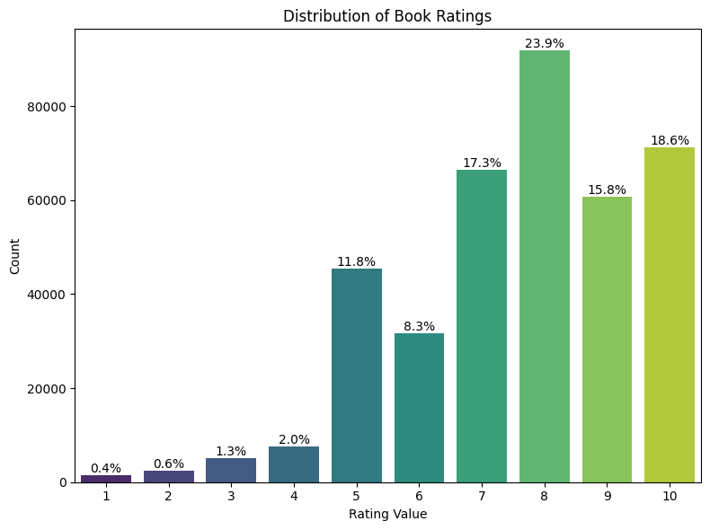

```python
import matplotlib.pyplot as plt
import seaborn as sns

plt.figure(figsize=(8, 6))

# Plotting the distribution of Book-Rating
sns.countplot(x='Rating', data=ratings_df, palette='viridis')
plt.title('Distribution of Book Ratings')
plt.xlabel('Rating Value')
plt.ylabel('Count')

# Adding percentage labels on top of bars
total = len(ratings_df)
for p in plt.gca().patches:
    percentage = f'{100 * p.get_height() / total:.1f}%'
    plt.gca().annotate(percentage,
                       (p.get_x() + p.get_width() / 2., p.get_height()),
                       ha='center', va='bottom')

plt.tight_layout()
plt.show()
```

This code cell imports `matplotlib.pyplot` and `seaborn` for visualization, sets up a figure with dimensions 8x6, defines the top 10 most reviewed books by using `value_counts().nlargest(10)` on the `ISBN` column of `ratings_df`, creates placeholder labels (`Book {ISBN}`) for the top books, generates a horizontal bar plot with `sns.barplot` using the 'viridis' palette to show the number of reviews per book, adds count labels to the right of each bar using `ax.text`, sets the title as 'Top 10 Most Reviewed Books' and labels the axes, adjusts the x-axis limit to accommodate the labels, applies `tight_layout` for spacing, saves the plot as `top_books.png` with 300 DPI, and displays the plot to highlight the most frequently reviewed books in the recommendation system dataset.

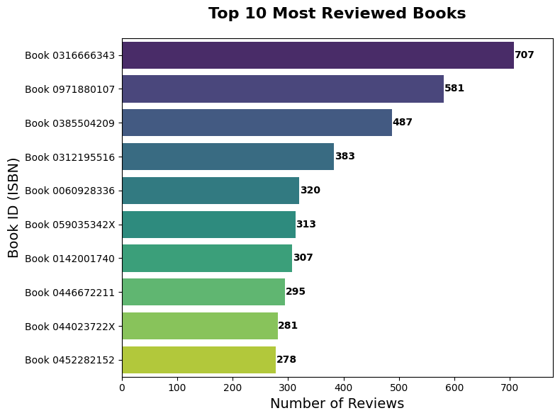

```python
import matplotlib.pyplot as plt
import seaborn as sns

plt.figure(figsize=(8, 6))

# Setting number of top books to show
n = 10

# Getting top n most reviewed books
book_counts = ratings_df['ISBN'].value_counts().nlargest(n)
book_labels = [f"Book {i}" for i in book_counts.index]

# Creating horizontal bar plot
ax = sns.barplot(x=book_counts.values, y=book_labels, palette='viridis')

# Adding count labels to the right of each bar
for i, count in enumerate(book_counts.values):
    ax.text(count + 1, i, str(count), va='center', fontweight='bold')

# Adding titles and labels
plt.title(f'Top {n} Most Reviewed Books', fontsize=16, fontweight='bold', pad=20)
plt.xlabel('Number of Reviews', fontsize=14)
plt.ylabel('Book ID (ISBN)', fontsize=14)

# Adjusting x-axis to make room for count labels
plt.xlim(0, max(book_counts.values) * 1.1)

plt.tight_layout()
plt.savefig('top_books.png', dpi=300, bbox_inches='tight')
plt.show()
```

This code cell imports `matplotlib.pyplot` and `seaborn` for visualization, initializes a figure with dimensions 8x6, sets the number of top users to display as 10, identifies the top 10 most active users by counting ratings per `User-ID` in `ratings_df` using `value_counts().nlargest(10)`, creates labels (`User {ID}`) for these users, generates a horizontal bar plot with `sns.barplot` using the 'Reds_d' palette to display the number of reviews per user, adds count labels to the right of each bar with `ax.text`, sets the title as 'Top 10 Most Active Users' and labels the axes, adjusts the x-axis limit to fit the labels, applies `tight_layout` for spacing, saves the plot as `top_users.png` with 300 DPI, and displays the plot to showcase the most active users in the recommendation system dataset.

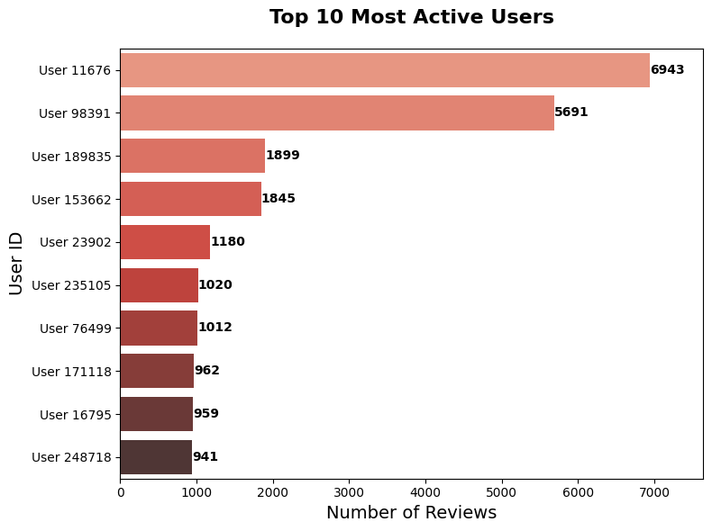

```python
import matplotlib.pyplot as plt
import seaborn as sns

plt.figure(figsize=(8, 6))

n = 10  # Number of top users to display

# Getting top n most active users by rating count
user_counts = ratings_df['User-ID'].value_counts().nlargest(n)
user_labels = [f"User {i}" for i in user_counts.index]

# Creating horizontal bar plot
ax = sns.barplot(x=user_counts.values, y=user_labels, palette='Reds_d')

# Adding count labels to the right of each bar
for i, count in enumerate(user_counts.values):
    ax.text(count + 0.5, i, str(count), va='center', fontweight='bold')

# Adding titles and labels
plt.title(f'Top {n} Most Active Users', fontsize=16, fontweight='bold', pad=20)
plt.xlabel('Number of Reviews', fontsize=14)
plt.ylabel('User ID', fontsize=14)

# Adjusting x-axis limit to make space for labels
plt.xlim(0, max(user_counts.values) * 1.1)

plt.tight_layout()
plt.savefig('top_users.png', dpi=300, bbox_inches='tight')
plt.show()
```

This code cell prepares the book ratings data for use with the `surprise` library, which is designed for building and analyzing recommender systems. It starts by defining a `Reader` object with a rating scale from 1 to 10, explicitly excluding any implicit 0 ratings. The data is then loaded into a `Dataset` object from a pandas DataFrame, specifically selecting the columns `User-ID`, `ISBN`, and `Book-Rating` while filtering out any entries with a `Book-Rating` of 0. The dataset is subsequently split into training and testing sets using an 75-25 split ratio, with a fixed random state of 42 to ensure reproducibility. This setup allows for the evaluation of the recommendation model's performance on unseen data.

```python
# 5: Prepare Data for Collaborative Filtering with SVD
# Preparing data in a format compatible with the surprise library
reader = Reader(rating_scale=(1, 10))  # Ratings range from 1 to 10 (excluding implicit 0 ratings)
data = Dataset.load_from_df(ratings_df[ratings_df['Book-Rating'] > 0][['User-ID', 'ISBN', 'Book-Rating']], reader)

# Splitting data into train and test sets to evaluate the model
trainset, testset = train_test_split(data, test_size=0.25, random_state=42)
```

```python
# Training and evaluate the SVD model
algo = SVD()
algo.fit(trainset)
predictions = algo.test(testset)
rmse = accuracy.rmse(predictions)
print(f"RMSE: {rmse}")
```

```
RMSE: 1.6358
RMSE: 1.6357596484373367
```

This code cell is dedicated to training the Singular Value Decomposition (SVD) model on the complete dataset to maximize its learning potential. It begins by creating a full training set from the dataset using `data.build_full_trainset()`, which consolidates all available data into a format suitable for training the model. An instance of the SVD model is then initialized. The model is trained on this comprehensive training set using the `fit` method, which optimizes the model's parameters to minimize prediction errors. Once the training process is complete, a success message, "SVD model trained successfully!", is printed, indicating that the model is now prepared to generate personalized book recommendations based on user preferences.

```python
# Training the model on the full dataset
trainset = data.build_full_trainset()
model = SVD()
model.fit(trainset)
print("SVD model trained successfully!")
```

```
SVD model trained successfully!
```

This code cell defines a function, `get_popular_books`, which retrieves a list of popular books based on the number of ratings they have received. The function takes an optional argument `n`, specifying the number of popular books to return, with a default value of 100. Inside the function, it groups the ratings data by `ISBN` and counts the number of ratings for each book, renaming the resulting count column to `count`. It then merges this data with the books data to obtain the book titles, sorts the merged data by the count of ratings in descending order, and returns the top `n` book titles. The function is called to get the list of popular books, which is then printed to confirm the number of books retrieved for use in the user interface dropdown menus.

```python
# 6: Functions for Recommendations and Popularity
# Functioning to get popular books for the dropdown menus
def get_popular_books(n=100):
    """
    Get a list of popular books based on the number of ratings.

    Args:
        n: Number of popular books to return

    Returns:
        List of book titles sorted by popularity
    """
    book_ratings = ratings_df.groupby('ISBN')['Book-Rating'].count().reset_index()
    book_ratings = book_ratings.rename(columns={'Book-Rating': 'count'})
    popular_books = pd.merge(book_ratings, books_df[['ISBN', 'Book-Title']], on='ISBN')
    popular_books = popular_books.sort_values('count', ascending=False).head(n)
    return popular_books['Book-Title'].tolist()

# Getting the list of popular books for the UI
popular_book_list = get_popular_books()
print(f"\nGot {len(popular_book_list)} popular books for the dropdown menus")
```

```
Got 100 popular books for the dropdown menus
```

This code cell defines a function, `recommend_books`, which generates book recommendations based on user-provided ratings. The function takes a list of tuples, `book_ratings`, where each tuple contains a book title and its corresponding rating, and an optional parameter `n_recommendations` specifying the number of recommendations to return. If no ratings are provided, it returns a message prompting the user to rate at least one book. The function then processes the ratings by assigning a new user ID, creating a DataFrame of new ratings, and merging these with the existing ratings data. It loads this combined data into a new dataset and trains an SVD model on it. The function predicts ratings for books the user hasn't rated, sorts these predictions, and returns the top recommendations along with their details. If any errors occur during this process, an error message is returned.

```python
# Function to get recommendations based on user ratings
def recommend_books(book_ratings, n_recommendations=5):
    """
    Generate book recommendations based on user ratings.

    Args:
        book_ratings: List of (book_title, rating) tuples
        n_recommendations: Number of recommendations to return

    Returns:
        DataFrame of recommendations, list of book details for explanations
    """
    if not book_ratings:
        return pd.DataFrame([{"Message": "Please rate at least one book first"}]), []

    try:
        new_user_id = ratings_df['User-ID'].max() + 1
        new_ratings = []
        for book_name, rating in book_ratings:
            if not book_name or rating <= 0:
                continue
            book_row = books_df[books_df['Book-Title'] == book_name]
            if book_row.empty:
                continue
            isbn = book_row.iloc[0]['ISBN']
            new_ratings.append({
                'User-ID': new_user_id,
                'ISBN': isbn,
                'Book-Rating': rating
            })

        if not new_ratings:
            return pd.DataFrame([{"Message": "Could not find any of the specified books"}]), []

        new_ratings_df = pd.DataFrame(new_ratings)
        all_ratings = pd.concat([ratings_df, new_ratings_df])
        new_data = Dataset.load_from_df(all_ratings[['User-ID', 'ISBN', 'Book-Rating']], Reader(rating_scale=(1, 10)))
        new_trainset = new_data.build_full_trainset()
        new_model = SVD()
        new_model.fit(new_trainset)

        rated_books = set(new_ratings_df['ISBN'].values)
        all_books = set(books_df['ISBN'].values)
        unrated_books = list(all_books - rated_books)

        predictions = []
        for isbn in unrated_books:
            est = new_model.predict(new_user_id, isbn).est
            predictions.append((isbn, est))

        predictions.sort(key=lambda x: x[1], reverse=True)
        top_n = predictions[:n_recommendations]

        results = []
        book_details = []
        for isbn, est in top_n:
            book_info = books_df[books_df['ISBN'] == isbn].iloc[0]
            results.append({
                'Book': book_info['Book-Title'],
                'Author': book_info['Book-Author'],
                'Predicted Rating': round(est, 2)
            })
            book_details.append({
                'title': book_info['Book-Title'],
                'author': book_info['Book-Author'],
                'predicted_rating': est
            })

        return pd.DataFrame(results), book_details

    except Exception as e:
        return pd.DataFrame([{"Message": f"Error: {str(e)}"}]), []
```

This code cell initializes the OpenAI client, which is necessary for interacting with OpenAI's API services. It imports the `OpenAI` class from the `openai` module and creates an instance of the client by providing an API key directly. The API key, which should be replaced with an actual key in a real-world scenario, authenticates the client and allows it to make requests to OpenAI's services, such as generating text or accessing other AI-powered features. This setup is crucial for integrating AI capabilities, like generating explanations for book recommendations, into the application.

```python
# 7: AI-Powered Explanation System
from openai import OpenAI

# Initializing the OpenAI client with the API key directly
client = OpenAI(api_key='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')  # Replace with your actual API key
```

This code cell defines a function, `generate_explanation`, which uses OpenAI's GPT model to create a friendly and conversational explanation for why a specific book is recommended to a user. The function takes several parameters: an OpenAI client instance, the title and author of the recommended book, the predicted rating for the book, and a list of books the user has rated. It constructs a prompt that includes these details and asks the model to generate an explanation highlighting connections to the user's taste, preferences for authors or genres, specific elements of the book that align with the user's preferences, and any interesting insights. The function then sends this prompt to the OpenAI API and returns the generated explanation. If an error occurs during this process, it returns an error message.

```python
# Function to generate explanation using OpenAI
def generate_explanation(client, book_title, book_author, predicted_rating, user_ratings):
    """
    Generate an explanation for why a book was recommended using OpenAI's GPT model.

    Args:
        client: OpenAI client instance
        book_title: Title of the recommended book
        book_author: Author of the recommended book
        predicted_rating: Predicted rating for the book
        user_ratings: List of (book_title, rating) tuples rated by the user

    Returns:
        str: Explanation for the recommendation
    """
    try:
        ratings_text = ""
        for title, rating in user_ratings:
            if title and rating > 0:
                ratings_text += f"- {title}: {rating}/10\n"

        prompt = f"""
As a book recommendation system, explain why the book "{book_title}" by {book_author}
with a predicted rating of {predicted_rating:.2f}/10 would be recommended to a user
who has rated the following books:

{ratings_text}

Give a friendly, conversational explanation that highlights:
1. Connections to the user's taste based on their ratings
2. Author or genre preferences the user might have
3. Specific elements of the recommended book that align with their preferences
4. Any interesting insights about this recommendation

Keep the explanation concise, around 3-4 sentences.
"""
        response = client.chat.completions.create(
            model="gpt-3.5-turbo",
            messages=[
                {"role": "system", "content": "You are a helpful book recommendation assistant."},
                {"role": "user", "content": prompt}
            ],
            max_tokens=500,
            temperature=0.7
        )
        return response.choices[0].message.content
    except Exception as e:
        return f"I couldn't generate an explanation at this time. Error: {str(e)}"
```

This code cell defines a function, `explain_recommendation`, which generates an explanation for why a specific book was recommended to a user. The function takes several parameters: an OpenAI client instance, the title of the selected book, a list of user ratings, and a list of recommended book details. It first checks if the client is properly initialized and if all necessary information is provided. It then searches for the selected book in the list of book details. If the book is found, it calls the `generate_explanation` function to create an explanation using the OpenAI client, providing details such as the book title, author, predicted rating, and user ratings. The generated explanation is then returned. If the book information is not found or any required information is missing, appropriate error messages are returned.

```python
# Function to explain a recommendation
def explain_recommendation(client, selected_book, user_ratings, book_details):
    """
    Generate explanation for a selected book.

    Args:
        client: OpenAI client instance
        selected_book: Title of the selected book
        user_ratings: List of user ratings
        book_details: List of recommended book details

    Returns:
        str: Explanation text
    """
    if not client:
        return "OpenAI client not properly initialized."
    if not selected_book or not user_ratings or not book_details:
        return "Please select a book from the recommendations first."

    selected_book_info = None
    for book in book_details:
        if book['title'] == selected_book:
            selected_book_info = book
            break

    if not selected_book_info:
        return "Book information not found."

    explanation = generate_explanation(
        client,
        selected_book_info['title'],
        selected_book_info['author'],
        selected_book_info['predicted_rating'],
        user_ratings
    )
    return explanation
```

This code cell defines three functions that are integral to the user interaction and state management within the book recommendation system. The `process_and_store` function processes user inputs, which include up to five book ratings and the desired number of recommendations. It filters out any invalid entries, calls the `recommend_books` function to generate recommendations, and returns the results along with the list of recommended book titles, user ratings, and book details. The `update_dropdown` function updates the dropdown menu choices in the user interface based on the list of recommended book titles. The `on_explain_btn_click` function handles the event when a user clicks the explain button, initializing the OpenAI client and calling the `explain_recommendation` function to generate an explanation for the selected book recommendation. These functions work together to provide a seamless and interactive user experience.

```python
# 8: User Interface with Gradio
# Function to process user inputs and store state
def process_and_store(book1, rating1, book2, rating2, book3, rating3, book4, rating4, book5, rating5, n_recs):
    user_ratings = [(book1, rating1), (book2, rating2), (book3, rating3), (book4, rating4), (book5, rating5)]
    user_ratings = [(book, rating) for book, rating in user_ratings if book and rating > 0]
    results_df, book_details = recommend_books(user_ratings, n_recs)
    book_titles = results_df["Book"].tolist() if "Book" in results_df.columns else []
    return results_df, book_titles, user_ratings, book_details

# Functioning to update dropdown choices
def update_dropdown(book_titles):
    return gr.Dropdown(choices=book_titles)

# Function to handle explain button clicks
def on_explain_btn_click(selected_book, user_ratings, book_details):
    from openai import OpenAI
    # Initializing the OpenAI client with the API key directly
    client = OpenAI(api_key='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')
    return explain_recommendation(client, selected_book, user_ratings, book_details)
```

This code cell creates a Gradio interface for the book recommendation system, allowing users to interact with the system through a web-based UI. The interface is structured with several sections: an input section where users can rate up to five books using dropdown menus and sliders, a section to specify the number of recommendations desired, and a submit button to generate recommendations. The recommendations are displayed in a DataFrame, and users can select a recommended book to receive an AI-generated explanation of why it was recommended. The interface also includes an educational section that explains how the recommendation system works, highlighting the use of Singular Value Decomposition (SVD) for collaborative filtering and OpenAI's GPT-3.5 for generating explanations. State variables are used to manage recommendations and user data, and event handlers connect the UI components to the backend functions. The app is launched with `demo.launch(share=True, debug=True)`, which generates a public URL for accessing the interface.

```python
# Creating Gradio interface
with gr.Blocks(title="Book Recommender System") as demo:
    gr.Markdown("# Book Recommendation System with AI Explanations")
    gr.Markdown("Rate up to five books to get personalized recommendations with explanations")
    gr.Markdown("*Using OpenAI API key from environment variables*")

    # Stating variables to store recommendations and user data
    recommended_books_state = gr.State([])
    user_ratings_state = gr.State([])
    book_details_state = gr.State([])

    # Inputting section - Rate books
    gr.Markdown("### Rate Your Books")
    with gr.Row():
        with gr.Column(scale=1):
            book1 = gr.Dropdown(choices=popular_book_list, label="Book 1")
            rating1 = gr.Slider(minimum=0, maximum=10, step=1, value=0, label="Rating")
        with gr.Column(scale=1):
            book2 = gr.Dropdown(choices=popular_book_list, label="Book 2")
            rating2 = gr.Slider(minimum=0, maximum=10, step=1, value=0, label="Rating")
        with gr.Column(scale=1):
            book3 = gr.Dropdown(choices=popular_book_list, label="Book 3")
            rating3 = gr.Slider(minimum=0, maximum=10, step=1, value=0, label="Rating")
        with gr.Column(scale=1):
            book4 = gr.Dropdown(choices=popular_book_list, label="Book 4")
            rating4 = gr.Slider(minimum=0, maximum=10, step=1, value=0, label="Rating")
        with gr.Column(scale=1):
            book5 = gr.Dropdown(choices=popular_book_list, label="Book 5")
            rating5 = gr.Slider(minimum=0, maximum=10, step=1, value=0, label="Rating")

    n_recs = gr.Slider(minimum=1, maximum=10, step=1, value=5, label="Number of Recommendations")
    submit_btn = gr.Button("📖 Get Recommendations", variant="primary")

    # Outputting section - Recommendations
    gr.Markdown("### Your Personalized Recommendations")
    recommendations = gr.Dataframe(label="Recommended Books")

    # Explanation section
    gr.Markdown("### Understand the Recommendation")
    selected_book = gr.Dropdown(label="Pick a Recommended Book", choices=[])
    explain_btn = gr.Button("❓ Why was this recommended?", variant="secondary")
    explanation = gr.Textbox(label="Explanation", lines=5)

    # Educational info section
    with gr.Accordion("About This System", open=False):
        gr.Markdown("""
        ### How This Recommender Works

        This system uses **Singular Value Decomposition (SVD)** for collaborative filtering
        and **OpenAI's GPT-3.5** model to generate human-like explanations for recommendations.

        **SVD** helps solve the sparsity problem in recommendation systems by decomposing the
        user-item matrix into latent factors that represent underlying patterns in user preferences.

        **The AI explanation component** enhances user trust by providing transparent, user-friendly
        explanations, making the system more engaging and reliable.

        The business value includes:
        - Increased user engagement through personalized recommendations
        - Enhanced trust through transparent AI explanations
        - Higher conversion rates with context-aware recommendations
        - Improved customer retention through better user experience
        """)

    # Connecting UI components with state management
    submit_btn.click(
        fn=process_and_store,
        inputs=[book1, rating1, book2, rating2, book3, rating3, book4, rating4, book5, rating5, n_recs],
        outputs=[recommendations, recommended_books_state, user_ratings_state, book_details_state]
    ).then(
        fn=update_dropdown,
        inputs=recommended_books_state,
        outputs=selected_book
    )

    explain_btn.click(
        fn=on_explain_btn_click,
        inputs=[selected_book, user_ratings_state, book_details_state],
        outputs=explanation
    )

# Launching the app
demo.launch(share=True, debug=True)
```

```
Colab notebook detected. This cell will run indefinitely so that you can see errors and logs. To turn off, set debug=False in launch().
* Running on public URL: https://cc6983b29ce68130c3.gradio.live

This share link expires in 1 week. For free permanent hosting and GPU upgrades, run `gradio deploy` from the terminal in the working directory to deploy to Hugging Face Spaces (https://huggingface.co/spaces)
```

[interactive chart not shown]